# DataTidy19RodoVaccComp

VaccCompData provides the raw data and the scripts used to process them for the paper ‘A comparison of antigen-specific T cell responses induced by six novel tuberculosis vaccine candidates’. Its installation is required to run the analysis script in the package VaccComp.

## Installation

To install VaccCompData, run:

```r
remotes::install_github("MiguelRodo/VaccCompData")
```

## Reproducing

The raw data are kept in the release `input` on GitHub, and must be saved to the `data-raw` directory (as specified in `_projr.yml`) to run the data.

Then run `projr::projr_build_dev()` to rebuild the projects. The project outputs will be saved to the `cache` directory (as specified in `_projr.yml`).

The schematic describes data processing by stage, specifying the outputs and processing files and providing details.

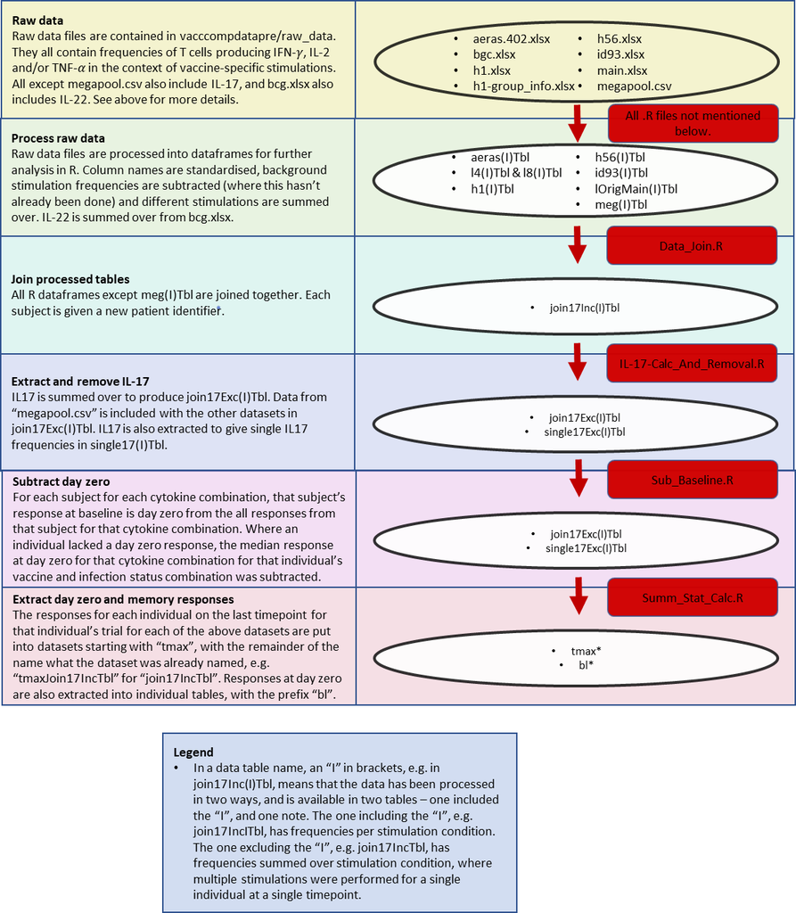

## Raw data

This vignette first describes each of the raw data files.

The raw data provided are not cell counts, but are the frequencies of cells producing some combination of the cytokines IFN$\gamma$, IL-2 and TNF. All raw data except that in the file megapool.csv also include IL-17, and the file bcg.xlsx also included IL-22.

### Raw data files

#### AERAS-402

- File name
  - aeras402.xlsx
- Columns
  - PatientID: participant identification number.
  - TubeName: stimulation condition.
  - TimePoint: Days since first vaccination.
  - CD4+2+17+G+T+ to CD8+2-17-G-T+
    - Indicates CD4/CD8 cell subset and cytokines produced.
    - CD[4/8]+ indicates whether cells are CD4 or CD8 T cells.
    - 2[+/-]17[+/-]G[+/-]T[+/-] indicates the cytokine combination. ‘2’ corresponds to IL-2, ‘17’ to IL-17, ‘G’ to IFN$\gamma$ and ‘T’ to TNF. A ‘+’ indicates that the preceding cytokine was produced, and a ‘-’ that it was not.
- Responses background subtracted?
  - Yes

#### BCG

- File name
  - bcg.xlsx
- Sheets
  - CD4 and CD8
  - Frequencies for CD4 and CD8 T cells, respectively.
- Columns
  - Sample: Sample label.
  - PTID: participant identification number.
  - Stimulation: stimulation condition.
  - Study Day
    - Days since initial vaccination.
    - ‘V08’ corresponds to day 0.
    - ‘V13’ corresponds to day 21.
    - ‘V15’ corresponds to day 35.
    - ‘V28’ corresponds to day 365.
    - QUESTION: need to find out what SC-3 and V01 are.
  - Group
    - The order of isonaizid, BCG and observation.
    - ‘IBO’ means isoniazid first, BCG second and observation last.
    - ‘OBI’ means observation first, BCG second and isoniazid last.
    - QUESTION: is this correct?
  - Subset: whether CD4 or CD8 T cells.
  - CD[4/8]+/2+ to CD[4/8]+/2-17-22-g-T-
    - Frequencies of cell subsets.
    - CD[4/8]+ indicates whether cells are CD4 or CD8 T cells.
    - ‘2’ corresponds to IL-2, ‘17’ to IL-17, ‘G’ to IFN$\gamma$, ‘T’ to TNF and ‘22’ to IL-22. A ‘+’ indicates that the preceding cytokine was produced, and a ‘-’ that it was not.
- Responses background subtracted?
  - No

#### H1:IC31

There are two files associated with H1. They are detailed separately below. THe first, h1-group_info.xlsx, was used to determine which study group each participant was allocated to, where the group determines the dose size and number of doses. The second, h1.xlsx, contains the immune response measurements.

- File name
  - h1-group_info.xlsx
- Columns
  - SubjectID: participant identification number.
  - Group
    - Study group number - 1, 2, 3 or 4.
    - Determines dose size and number of doses.
- File name
  - h1.xlsx
- Columns
  - Sample: Sample label.
  - $FIL: Slightly shortened sample label.
  - SAMPLE ID: participant id number.
  - Group
    - Mycobacterium tuberculosis infection status according to a quantiferon cut-off of 0.35 at time of first vaccination.
    - ‘2 denotes infected, and ’1’ uninfected.
  - Timepoint: days since first vaccination.
  - TUBE NAME: stimulation condition.
  - CD4+/G+T+2+17+ to CD8+/G-T-2-17-
    - Indicates CD4/CD8 cell subset and cytokines produced.
    - CD[4/8]+ indicates whether cells are CD4 or CD8 T cells.
    - G[+/-]T[+/-]2[+/-]17[+/-] indicates the cytokine combination. ‘2’ corresponds to IL-2, ‘17’ to IL-17, ‘G’ to IFN$\gamma$ and ‘T’ to TNF. A ‘+’ indicates that the preceding cytokine was produced, and a ‘-’ that it was not.
- Responses background subtracted?
  - No

#### ID93+GLA-SE

- File name
  - id93.xlsx
- Columns
  - SAMPLE ID: participant identification number.
  - Date of Blod Draw: date of blood draw.
  - COHORT
    - Study group number - 1, 2, 3 or 4.
    - Determines dose size and number of doses.
  - Study Day: days since first vaccination.
  - RANDOMISATION
    - Whether or not a vaccine or placebo was given to the participant.
    - ‘ID93+GLA/SE’ means that the participant was given a vaccine, and ‘Placebo’ that the participant was given a placebo.
  - QFT Status
    - Mycobacterium tuberculosis infection status according to a quantiferon cut-off of 0.35 at time of first vaccination.
    - ‘QFT+’ denotes infected, and ‘QFT-’ uninfected.
  - TUBE NAME: stimulation condition.
  - CD8+/G+T+2+17+ to CD4+/G-T-2-17+
    - Frequencies of cell subsets.
    - CD[4/8]+ indicates whether cells are CD4 or CD8 T cells.
    - ‘2’ corresponds to IL-2, ‘17’ to IL-17, ‘G’ to IFN$\gamma$ and ‘T’ to TNF. A ‘+’ indicates that the preceding cytokine was produced, and a ‘-’ that it was not.
- Responses background subtracted?
  - No

#### Megapool

- File name
  - megapool.csv
- Columns
  - Donor.ID: participant identification number.
  - SubjectType
    - Mycobacterium tuberculosis infection status according to a quantiferon cut-off of 0.35 at time of first vaccination.
    - All subjects have value ‘LTBI’ for this column, meaning that their quantiferon score was greater than 0.35.
    - Stimulation: stimulation condition.
  - CD4.Gneg2negTpos…Count to CD8.Gpos2posTneg…Freq..of.Parent
    - Cell subset frequency of count.
    - CD[4/8] indicates whether the cells are CD4 or CD8 T cells.
    - ‘2’ corresponds to IL-2, ‘17’ to IL-17, ‘G’ to IFN$\gamma$ and ‘T’ to TNF. A ‘pos’ indicates that the preceding cytokine was produced, and a ‘neg’ that it was not.
- Responses background subtracted?
  - No

#### M72:AS01E and MVA85A

- File name
  - main.xlsx
- Columns
  - PatientID: patient identification number.
  - TubeName: stimulation condition.
  - Protocol ID: protocol identification number.
  - Vaccine: vaccine administered.
  - UniqueID: concatenation of PatientID, TubeName, Vaccine and TimePoint.
  - Infxn
    - Mycobacterium tuberculosis infection status according to a quantiferon cut-off of 0.35 at time of first vaccination.
    - ‘positive’ denotes infected, and ‘negative’ uninfected.
  - TimePoint: time since first vaccination.
  - CD4posGpos2pos17posTpos to TotCD8posTpos
    - Frequencies of cell subsets.
    - CD[4/8]pos indicates whether cells are CD4 or CD8 T cells.
    - ‘2’ corresponds to IL-2, ‘17’ to IL-17, ‘G’ to IFN$\gamma$ and ‘T’ to TNF. A ‘pos’ indicates that the preceding cytokine was produced, and a ‘neg’ that it was not.
- Responses background subtracted?
  - Yes

### Data processing schematic